# A Swarm of GPU Sparks

About GPU-enabled Docker Swarms

recraft@pm.me https://recraft.me (Recraft)https://github.com/recraft  
2019-02-09

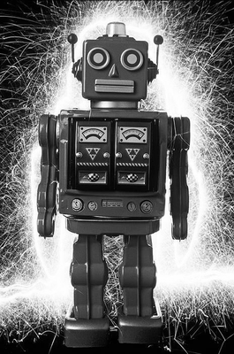

Can we set up a Docker Swarm cluster with nodes that can run Spark?

Yes, here is a nice write-up stepping through [how to run a Docker Swarm-based cluster of Spark nodes](https://medium.com/@aoc/running-spark-on-docker-swarm-777b87b5aa3).

Note however that this guide does not provide a GPU-enabled Docker Swarm-based cluster running Spark.

## GPU-enabled Swarm

So how can we add GPU capabilities to the nodes?

Some IaaS-providers provide GPU-enabled environments. For example, using the Amazon Cloud, provision a [deep learning base AMI for Ubuntu](https://aws.amazon.com/marketplace/pp/B077GCZ4GR), like so:

```
docker-machine create --driver amazonec2 --amazonec2-ami=ami-086062166ec8340ac \
  --amazonec2-open-port 8000 --amazonec2-region eu-west-1 aws-sandbox
```

This host needs to be updated with `nvidia-docker2` - this guide mentions the procedure [here](https://medium.com/@kyeongwook.ma/deploy-nvidia-docker-to-docker-swarm-service-in-10-mins-4ba603048e85), summarized like so:

```
docker-machine ssh aws-sandbox
sudo apt-get -y install nvidia-docker2
docker run --runtime=nvidia --rm nvidia/cuda nvidia-smi
```

We then need to configure the nodes to [utilize the GPU](http://cowlet.org/2018/05/21/accessing-gpus-from-a-docker-swarm-service.html) like so:

```
export GPU_ID=`nvidia-smi -a | grep UUID | awk '{print substr($4,0,12)}'`
sudo mkdir -p /etc/systemd/system/docker.service.d
cat <<EOF | sudo tee --append /etc/systemd/system/docker.service.d/override.conf
[Service]
ExecStart=
ExecStart=/usr/bin/dockerd -H fdd:// --default-runtime=nvidia --node-generic-resource gpu=${GPU_ID}
EOF
sudo sed -i '1iswarm-resource = "DOCKER_RESOURCE_GPU"' /etc/nvidia-container-runtime/config.toml
sudo systemctl daemon-reload
sudo systemctl start docker
```

More nodes can be bootstrapped and added in the same manner to the swarm.

## Deploying services and stacks

On the swarm, GPU-aware tensorflow services can now be launched. A ten replica strong set of Spark worker nodes could be launched like so:

```
docker service create --generic-resource "gpu=1" --replicas 10 \
  --name sparkWorker <image_name> \
  "service ssh start && \
  /opt/spark/bin/spark-class org.apache.spark.deploy.worker.Worker spark://<spark_master_ip>:7077\"
```

It should now also be possible to define a stack to run on the swarm, using Docker Compose, by providing relevant constraints in a .yml-file similar to what is done here:

```
https://github.com/infsaulo/docker-spark/blob/master/docker-compose.yml
https://github.com/aocenas/spark-docker-swarm/blob/master/provision.sh
```

## Prefer Open Science Grid over Amazon?

It may be that your local computing grid infrastructure supports running GPU-enabled Docker or Singularity containers.

Test for example to use the image provided from Docker Hub named `opensciencegrid/tensorflow-gpu` with your local grid computing IaaS-provider and see how it goes.

The [Open Science Grid](https://opensciencegrid.org/about/introduction/) has some information on [GPU-enabled options](https://support.opensciencegrid.org/support/solutions/articles/12000024676-docker-and-singularity-containers) with information on how to configure GPU images including an example of how to [create custom GPU-enabled Dockerfiles](https://github.com/opensciencegrid/osgvo-tensorflow-gpu/blob/master/Dockerfile), available on GitHub.